# Neural Networks for Bank Churn Prediction

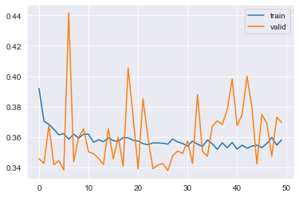

```
              precision    recall  f1-score   support

           0       0.87      0.97      0.92      1589
           1       0.70      0.35      0.47       346

    accuracy                           0.86      1935
   macro avg       0.79      0.66      0.69      1935
weighted avg       0.84      0.86      0.84      1935

[[1537   52]
 [ 225  121]]
Accuracy: 0.857
Loss: 0.386
```

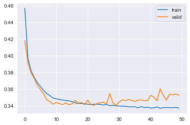

```
              precision    recall  f1-score   support

           0       0.88      0.95      0.92      1589
           1       0.66      0.41      0.51       346

    accuracy                           0.86      1935
   macro avg       0.77      0.68      0.71      1935
weighted avg       0.84      0.86      0.84      1935

[[1514   75]
 [ 203  143]]
Accuracy: 0.856
Loss: 0.362
```

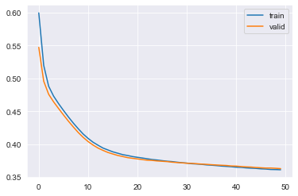

```
              precision    recall  f1-score   support

           0       0.88      0.97      0.92      1589
           1       0.73      0.38      0.50       346

    accuracy                           0.86      1935
   macro avg       0.80      0.67      0.71      1935
weighted avg       0.85      0.86      0.85      1935

[[1540   49]
 [ 215  131]]
Accuracy: 0.864
Loss: 0.359
```

```python
lr = [0.01, 0.001, 0.0001]
for i in lr:
    model = Sequential()
    model.add(Dense(13,activation='relu'))
    model.add(Dense(10, activation ='relu'))
    model.add(Dense(5, activation ='relu'))
    model.add(Dense(2,activation='softmax'))
    optimizer = keras.optimizers.RMSprop(lr=i)
    model.compile(loss='categorical_crossentropy',optimizer=optimizer, metrics=['accuracy'])
    history = model.fit(X_train, y_train, epochs= 50, validation_split = 0.2, batch_size = 10, verbose = False)
    hist  = pd.DataFrame(history.history)
    hist['epoch'] = history.epoch
    plt.plot(hist['loss'])
    plt.plot(hist['val_loss'])
    plt.legend(("train", "valid") , loc =0)
    plt.show()
    results = pd.DataFrame()
    results['Actual'] = y_test.values
    y_pred = model.predict(X_test)
    predictions = []
    for pred in y_pred:
        predictions.append(np.argmax(pred))
    results['Probability that output is 0'] = model.predict_proba(X_test)[:,0]
    results['Probability that output is 1'] = model.predict_proba(X_test)[:,1]
    results['Predicted'] = predictions
    #Sklearn has threshold of 0.5 but here I explicitly set it to 0.5 to be thorough
    results['Predicted'] = results['Probability that output is 1'].map(lambda x: 1 if x > 0.5 else 0)
    GetCM(y_pred, results)
    loss, accuracy = model.evaluate(X_test, caty_test, verbose = 0)
    print('Accuracy: %.3f'  % accuracy)
    print('Loss: %.3f' % loss)
```

Insights: The convergence is a lot smoother in the 0.0001 learning rate trial, this seems to be a good value for this model. The loss for the validation set is mostly steadily decreasing, which is an improvement from the previous trials. From higher learning rates, I note that the validation loss does not decrease along with the training set, which is undesirable.  
The accuracy for the 0.0001 learning rate model is pretty much the same as the other trials. However, I got the best convergence using this learning rate and will proceed with this

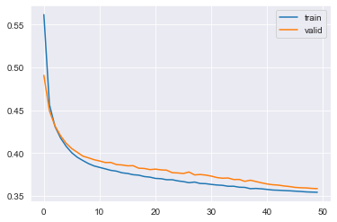

```
              precision    recall  f1-score   support

           0       0.87      0.96      0.91      1589
           1       0.65      0.36      0.47       346

    accuracy                           0.85      1935
   macro avg       0.76      0.66      0.69      1935
weighted avg       0.83      0.85      0.83      1935

[[1522   67]
 [ 220  126]]
Accuracy: 0.852
Loss: 0.364
```

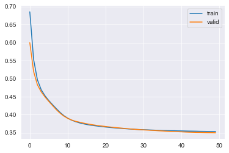

```
              precision    recall  f1-score   support

           0       0.87      0.96      0.91      1589
           1       0.66      0.37      0.47       346

    accuracy                           0.85      1935
   macro avg       0.77      0.66      0.69      1935
weighted avg       0.84      0.85      0.84      1935

[[1524   65]
 [ 219  127]]
Accuracy: 0.853
Loss: 0.360
```

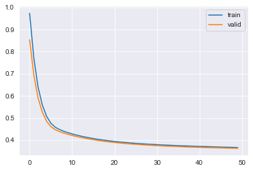

```
              precision    recall  f1-score   support

           0       0.86      0.97      0.91      1589
           1       0.69      0.28      0.40       346

    accuracy                           0.85      1935
   macro avg       0.78      0.63      0.66      1935
weighted avg       0.83      0.85      0.82      1935

[[1545   44]
 [ 248   98]]
Accuracy: 0.849
Loss: 0.365
```

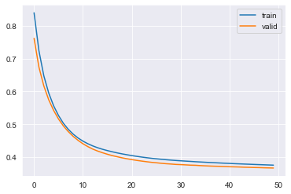

```
              precision    recall  f1-score   support

           0       0.86      0.97      0.91      1589
           1       0.66      0.27      0.39       346

    accuracy                           0.84      1935
   macro avg       0.76      0.62      0.65      1935
weighted avg       0.82      0.84      0.82      1935

[[1541   48]
 [ 252   94]]
Accuracy: 0.845
Loss: 0.366
```

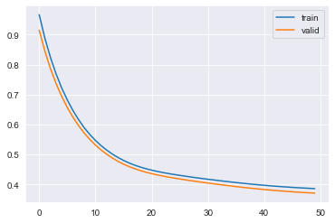

```
              precision    recall  f1-score   support

           0       0.85      0.98      0.91      1589
           1       0.73      0.21      0.32       346

    accuracy                           0.84      1935
   macro avg       0.79      0.60      0.62      1935
weighted avg       0.83      0.84      0.81      1935

[[1563   26]
 [ 274   72]]
Accuracy: 0.845
Loss: 0.374
```

```python
#Now, I will tune the batch size parameter
batches = [5, 10, 30, 50, 100]
for i in batches:
    model = Sequential()
    model.add(Dense(13,activation='relu'))
    model.add(Dense(10, activation ='relu'))
    model.add(Dense(5, activation ='relu'))
    model.add(Dense(2,activation='softmax'))
    optimizer = keras.optimizers.RMSprop(lr=0.0001)
    model.compile(loss='categorical_crossentropy',optimizer=optimizer, metrics=['accuracy'])
    history = model.fit(X_train, y_train, epochs= 50, validation_split = 0.2, batch_size = i, verbose = False)
    hist  = pd.DataFrame(history.history)
    hist['epoch'] = history.epoch
    plt.plot(hist['loss'])
    plt.plot(hist['val_loss'])
    plt.legend(("train", "valid") , loc =0)
    plt.show()
    results = pd.DataFrame()
    results['Actual'] = y_test.values
    y_pred = model.predict(X_test)
    predictions = []
    for pred in y_pred:
        predictions.append(np.argmax(pred))
    results['Probability that output is 0'] = model.predict_proba(X_test)[:,0]
    results['Probability that output is 1'] = model.predict_proba(X_test)[:,1]
    results['Predicted'] = predictions
    #Sklearn has threshold of 0.5 but here I explicitly set it to 0.5 to be thorough
    results['Predicted'] = results['Probability that output is 1'].map(lambda x: 1 if x > 0.5 else 0)
    GetCM(y_pred, results)
    loss, accuracy = model.evaluate(X_test, caty_test, verbose = 0)
    print('Accuracy: %.3f'  % accuracy)
    print('Loss: %.3f' % loss)
```

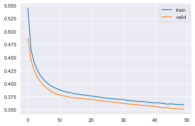

```
              precision    recall  f1-score   support

           0       0.87      0.95      0.91      1589
           1       0.61      0.37      0.46       346

    accuracy                           0.85      1935
   macro avg       0.74      0.66      0.69      1935
weighted avg       0.83      0.85      0.83      1935

[[1508   81]
 [ 217  129]]
Accuracy: 0.846
Loss: 0.364
```

```python
#Finally, I try three different optimizers: RMSProp, Adam, and SGD
model = Sequential()
model.add(Dense(13,activation='relu'))
model.add(Dense(10, activation ='relu'))
model.add(Dense(5, activation ='relu'))
model.add(Dense(2,activation='softmax'))
optimizer = keras.optimizers.RMSprop(lr=0.0001)
model.compile(loss='categorical_crossentropy',optimizer=optimizer, metrics=['accuracy'])
history = model.fit(X_train, y_train, epochs= 50, validation_split = 0.2, batch_size = 5, verbose = False)
hist  = pd.DataFrame(history.history)
hist['epoch'] = history.epoch
plt.plot(hist['loss'])
plt.plot(hist['val_loss'])
plt.legend(("train", "valid") , loc =0)
plt.show()
results = pd.DataFrame()
results['Actual'] = y_test.values
y_pred = model.predict(X_test)
predictions = []
for pred in y_pred:
    predictions.append(np.argmax(pred))
results['Probaility that output is 0'] = model.predict_proba(X_test)[:,0]
results['Probability that output is 1'] = model.predict_proba(X_test)[:,1]
results['Predicted'] = predictions
#Sklearn has threshold of 0.5 but here I explicitly set it to 0.5 to be thorough
results['Predicted'] = results['Probability that output is 1'].map(lambda x: 1 if x > 0.5 else 0)
GetCM(y_pred, results)
loss, accuracy = model.evaluate(X_test, caty_test, verbose = 0)
print('Accuracy: %.3f'  % accuracy)
print('Loss: %.3f' % loss)
```